# 52414: Lab 2

Mariya Mordvova and Sapir Galzman

June 1, 2021

## *Lab 2: Visualization Through `ggplot`*

**Contents**:

- Q0. Submission Instructions
- Q1. Basic Statistics (30 pt)
- Q2. Scouting Report (30 pt)
- Q3. Model Building (30 pt)
- Q4. Fix Problematic Plots (10 pt)

### Q0.Submission Instructions

This lab will be submitted in pairs using GitHub (if you don’t have a pair, please contact us).  
Please follow the steps in the [GitHub-Classroom Lab 2](https://classroom.github.com/g/6_Wy5z44) to create your group’s Lab 2 repository.  
**Important: your team’s name must be `FamilyName1_Name1_and_FamilyName2_Name2`**.  
You can collaborate with your partner using the git environment; You can either make commits straight to master, or create individual branches (recommended). However, once done, be sure to merge your branches to master - you will be graded using the most recent *master* version - your last push and merge before the deadline.  
**Please do not open/review other peoples’ repositories - we will be notified by GitHub if you do.**

Your final push should include this Rmd file (with your answers) together with the html file that is outputted automatically by knitr when you knit the Rmd. Anything else will be disregarded. In addition, please adhere to the following file format:  
`Lab_2_FamilyName1_Name1_and_FamilyName2_Name2.Rmd/html`

Some questions may require data wrangling and manipulation which you need to decide on.  
In some graphs you may need to change the graph limits. If you do so, please include the outlier points you have removed in a separate table.

Show numbers in plots/tables using standard digits and not scientific display. That is: 90000000 and not 9e+06.  
Round numbers to at most 3 digits after the dot - that is, 9.456 and not 9.45581451044

The required libraries are listed below the instructions. You are allowed to add additional libraries if you want. If you do so, *please explain what libraries you’ve added, and what is each new library used for*.

#### Background:

You’ve been hired as a data analyst at at football (soccer) club. Since this is a small and under-funded club, you will not have access to real-football data, but to data from the football computer game fifa18. Your job is to analyze this dataset and extract meaningful insights from the data in order to help your club make better decisions.

#### Data File:

You will load and analyze the fifa18 football dataset file called “fifa_data.csv”.  
The dataset contains detailed information about each player in the game, including: names, age, nationality, overall ability, estimated potential ability, current club and league, market value, salary (wage), ability at different football skills (also called ‘attributes’, e.g. Ball.control, Sprint.speed …), ability to play at different position in the game (CF, CM, …) and the preferred positions of the player.

Required Libraries:

```r
library(ggplot2)
library(dplyr)
library(corrplot)
library(scales)   # needed for formatting y-axis labels to non-scientific type
library(radarchart)
library(tidyr)
library(tidyverse)
library(reshape2) # melt
library(ggthemes)
library(rworldmap) # world map
library(modelr)
library(radarchart) #Spider chart
############################################
library(e1071) #Q1.c -  skewness() and kurtosis()
library(grid) # geom_segment
library(ggrepel)# Use ggrepel::geom_label_repel
library(viridis) #pretty colors for ggplot

rm(list=ls())

options("scipen"=100, "digits"=4)  # avoid scientific display of digits. Take 4 digits.
```

## Q1. Basic Univariate Statistics (30 pt)

First, you are requested to load the fifa18 dataset and find and display general information about the players. Loading the data:

```r
fifa_players <- data.frame(read.csv(url("https://raw.githubusercontent.com/DataScienceHU/DataAnalysisR_2020/master/data/fifa_data.csv")))

# Pre-processing:
for (i in c(3,6,7,10:71)) {
  fifa_players[,i]<-as.numeric((fifa_players[,i]))
}
fifa<-na.omit(fifa_players)
fifa_players <- fifa
fifa_players_info <- fifa[,c(1:11)] # players general info
fifa_players_attribures <- fifa[,c(1,12:45, 6)] # players different skills. Add overall
fifa_players_positions <- fifa[,c(1,46:72,6,7)] # players ability at different positions . Add overall
fifa_players_indicators <- fifa[,c(1,6,7,10,11)] # players general ability
```

1. Make a plot showing the `overall` ability distribution of all players. How skewed is the distributions? does it have fat tails?  
   Plot on top of the `overall` distribution a Normal distribution matching its first two moments. Is the distribution described well by a Normal distribution? explain.

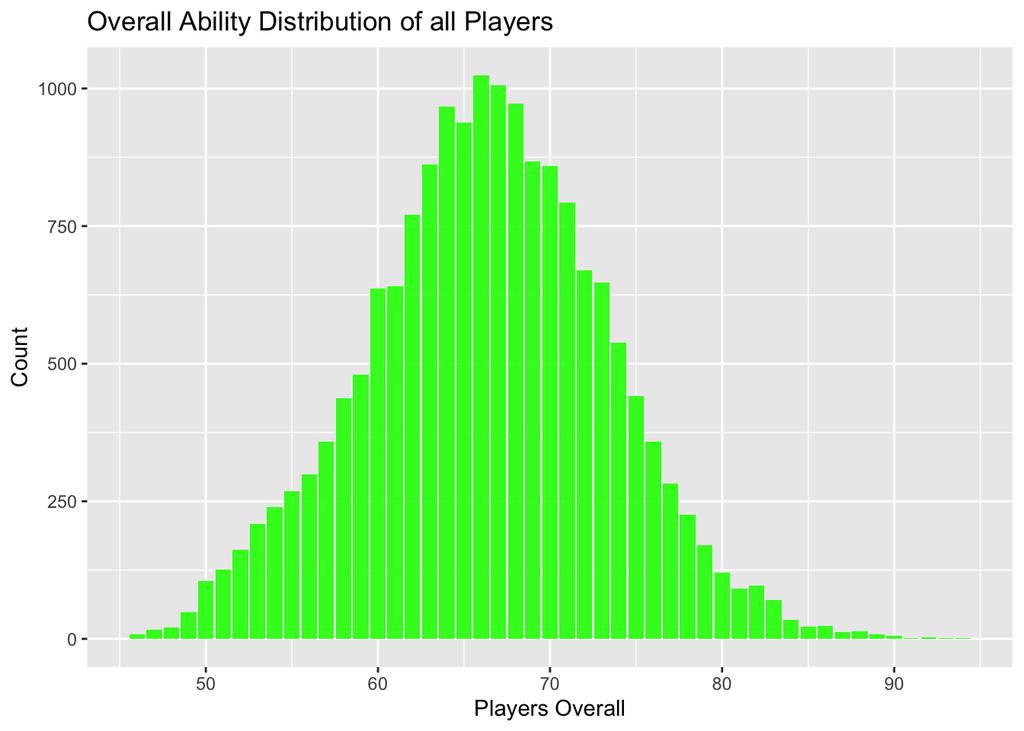

```r
ggplot(data = fifa_players,aes(x=Overall))+
  geom_bar(fill = "green" , alpha = 0.9)+
  xlab("Players Overall")+
  ylab("Count")+
  labs(title="Overall Ability Distribution of all Players")
```

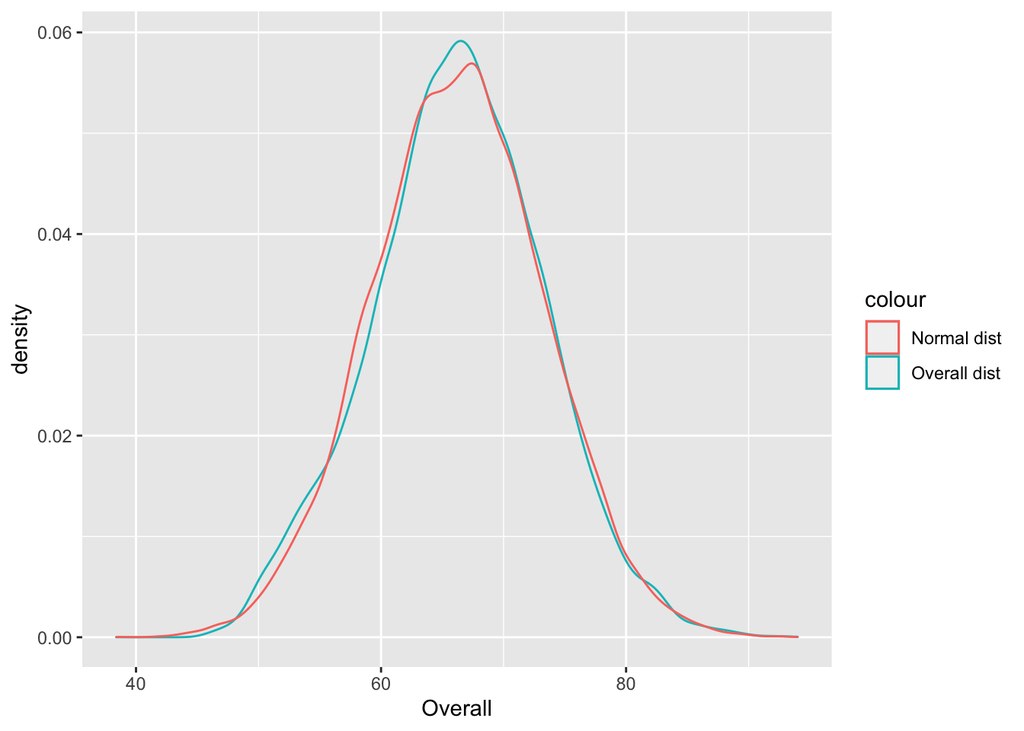

```r
ggplot(fifa_players)+geom_density(aes(Overall,col="Overall dist"))+geom_density(aes(rnorm(16955,mean=mean(fifa_players$Overall),sd=sd(fifa_players$Overall)),col="Normal dist"))
```

```r
cat("The skewness of players overall ability is ",skewness(fifa_players$Overall)) #checking skewed
```

```
## The skewness of players overall ability is  0.008293
```

```r
cat("   The kurtosis of players overall ability is ", kurtosis(fifa_players$Overall)) #checking fat tails
```

```
##    The kurtosis of players overall ability is  -0.02102
```

*The skewness is 0.008293 it is a positive number => we have long right tail, however, the number is really small => the tails are almost symmetrical. The kurtosis is -0.02102 it is a negative number => relatively short tails comparing to Normal Distribution, however, again the number is really close to 0, so the tails are almost equal. By plotting on top of the `overall` distribution a Normal distribution matching its first two moments, we can see that the distribution described well by a Normal distribution, the lines are almost overlap, especially on the right tail. However, we can see that the peak of Normal Dist is lower then the peak of Overall dist.*

2. Make a plot comparing the multiple `overall` ability *distributions* of players according to the `continent` of the players. Describe which continents have especially good/bad players.

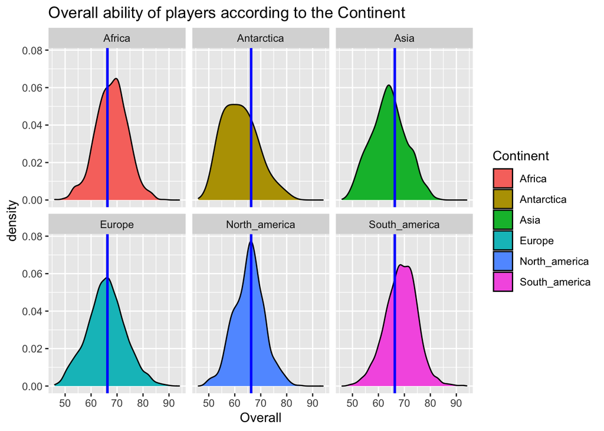

```r
ggplot(data = fifa_players, aes(x=Overall))+
  geom_density(aes(fill = Continent))+
  facet_wrap(~ Continent, ncol = 3)+
  geom_vline(xintercept = mean(fifa_players$Overall), col= "blue", lwd = 1)+
  ggtitle(label = "Overall ability of players according to the Continent")
```

```r
group_means <- tapply(fifa_players$Overall,fifa_players$Continent, FUN = mean) #means in decreasing order
group_means <- as.data.frame(sort(x = group_means, decreasing = T)) #new dataframe of country means in decreasing order
colnames(group_means) <- c("Mean")
print(group_means)
```

```
##                Mean
## South_america 68.72
## Africa        67.89
## Europe        65.82
## North_america 65.48
## Asia          63.98
## Antarctica    62.15
```

*We did the blue total overall mean line to make the comparison between continents easier. South America and Africa have especially good players (since we can see from histogram that their overall mean is greater then the total mean(blue line)), while, Asia and Antarctica have the worst players since their means are much smaller than the total overall mean of continents.*

3. Make a plot showing the density of players’ `value` distribution.  
   Next, make a separate plot showing the density distribution of the *log* of players’ `value`.  
   Which of the two visualizations is better? explain.

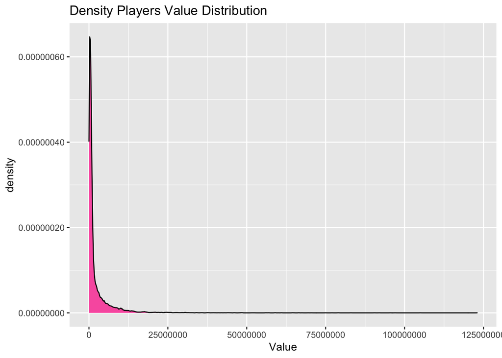

```r
ggplot(data = fifa_players, aes(x=Value)) +
  scale_y_continuous(labels = scales::comma)  +
  geom_density(fill = "deeppink" , alpha = 0.7) +
  ggtitle(label = "Density Players Value Distribution")
```

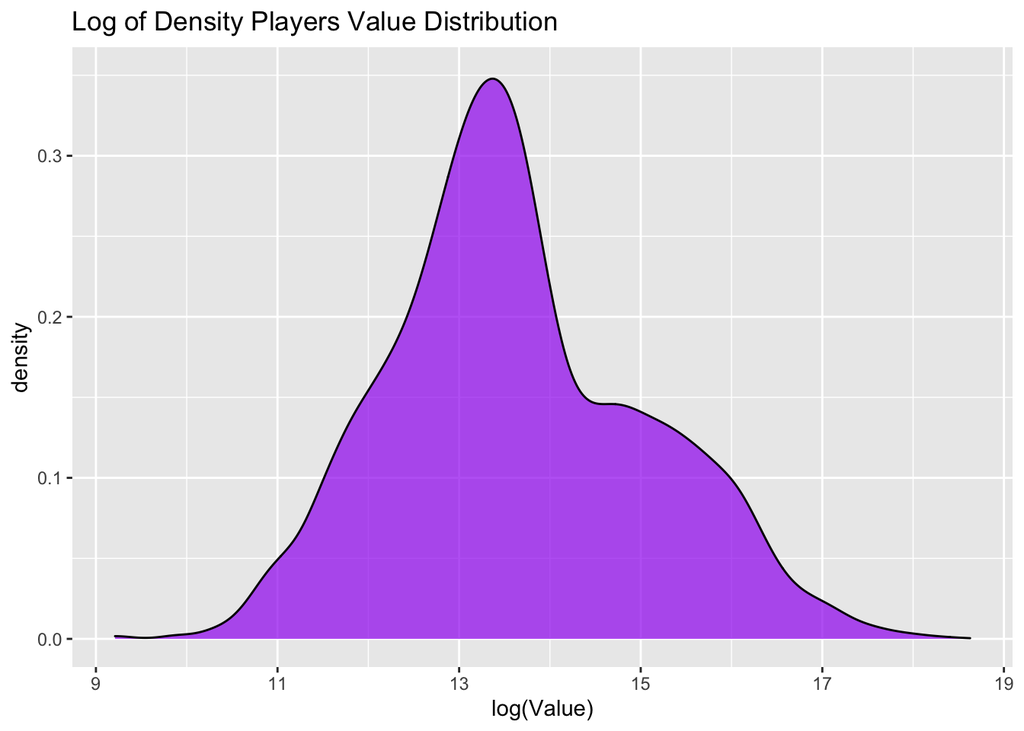

```r
###log plot
no_zeroes_values <- filter(.data = fifa_players, Value > 0) ##to do log function we will get rid of zero values

ggplot(data = no_zeroes_values, aes(x=log(Value))) +
  geom_density(fill = "purple" , alpha = 0.7)+
  ggtitle(label = "Log of Density Players Value Distribution")+
  xlim(min(log(no_zeroes_values$Value)),max(log(no_zeroes_values$Value)))+
  ylim(0 , 0.35)
```

*The plot of density of players’ `value` distribution is unreadable, doesn’t give any information. On the other hand, the log plot better represents the density, we can see the peak, tails, compare it to normal distribution. The log plot undoubtfully gives more information.* d. Are the top-10 players with the highest `value` also the top-10 best players in terms of `overall` ability? Show tables for both and compare.  
Who is the best player not in the top-10 valued players?

```r
top_value<-(head(arrange(fifa_players[,c(2,6,10)], desc(fifa_players$Value) ), 10)) #top-10 best players in terms of 'value'
top_overall<-(head(arrange(fifa_players[,c(2,6,10)], desc(fifa_players$Overall) ), 10)) #top-10 best players in terms of `overall` ability
best_not_valued <- (head(anti_join(x= top_overall, y= top_value, by= "Name"),1))
print("Top-10 players with the highest `value`")
```

```
## [1] "Top-10 players with the highest `value`"
```

```r
print(top_value)
```

```
##                 Name Overall     Value
## 1             Neymar      92 123000000
## 2           L. Messi      93 105000000
## 3          L. Suárez      92  97000000
## 4  Cristiano Ronaldo      94  95500000
## 5     R. Lewandowski      91  92000000
## 6          E. Hazard      90  90500000
## 7       K. De Bruyne      89  83000000
## 8          P. Dybala      88  79000000
## 9           T. Kroos      90  79000000
## 10        G. Higuaín      90  77000000
```

```r
print("Top-10 players best players in terms of `overall` ability")
```

```
## [1] "Top-10 players best players in terms of `overall` ability"
```

```r
print(top_overall)
```

```
##                 Name Overall     Value
## 1  Cristiano Ronaldo      94  95500000
## 2           L. Messi      93 105000000
## 3             Neymar      92 123000000
## 4           M. Neuer      92  61000000
## 5          L. Suárez      92  97000000
## 6     R. Lewandowski      91  92000000
## 7          E. Hazard      90  90500000
## 8             De Gea      90  64500000
## 9         G. Higuaín      90  77000000
## 10          T. Kroos      90  79000000
```

```r
print("The best players not in the top-10 valued players")
```

```
## [1] "The best players not in the top-10 valued players"
```

```r
print(best_not_valued)
```

```
##       Name Overall    Value
## 1 M. Neuer      92 61000000
```

```r
print("The best player not in the top-10 valued players is M.Neuer")
```

```
## [1] "The best player not in the top-10 valued players is M.Neuer"
```

*The top-10 players with the highest `value` are almost the same as the top-10 best players in terms of `overall` ability, however, their order differ. Moreover, M. Neuer and De Gea are players that are in the best player and are not in the top-10 valued players.*

5. Show a table of the *10* *youngest* and *10* *oldest* teams in terms of *average* players `age`.

```r
# creating a table of the players with their mean ages:
players_age <- as.data.frame(aggregate(fifa_players$Age, by = list(fifa_players$Name), FUN = mean))
#colnames(players_age) <- c("Name", "Mean of Age")


print("Top 10 youngest players in terms of average players age")
```

```
## [1] "Top 10 youngest players in terms of average players age"
```

```r
head(arrange(players_age,(x)),10)
```

```
##          Group.1  x
## 1       A. Gomes 16
## 2      E. Håland 16
## 3     E. Vignato 16
## 4   G. McEachran 16
## 5        J. Hove 16
## 6      J. Romero 16
## 7   Javi Vázquez 16
## 8      K. Pierie 16
## 9  L. Geertruida 16
## 10     L. Pintor 16
```

```r
print("Top 10 oldest players in terms of average players age")
```

```
## [1] "Top 10 oldest players in terms of average players age"
```

```r
head(arrange(players_age, desc(x)),10)
```

```
##          Group.1  x
## 1  B. Richardson 47
## 2   E. El Hadary 44
## 3       D. Coyne 43
## 4         C. Day 41
## 5      K. Wæhler 41
## 6           Quim 41
## 7       B. Nivet 40
## 8      L. Butrón 40
## 9       M. Brown 40
## 10    M. Candelo 40
```

## Q2. Scouting Report (30 pt)

You are in charge of the scouting division. The goal of this division is to follow players’ `potential` and `overall` ability, and identify undervalued players - that is, players whose current value is lower compared to what would be expected based on their predicted future ability.

1. Plot the *average* `potential` ability by `age` of all players, for players 35 years old or younger

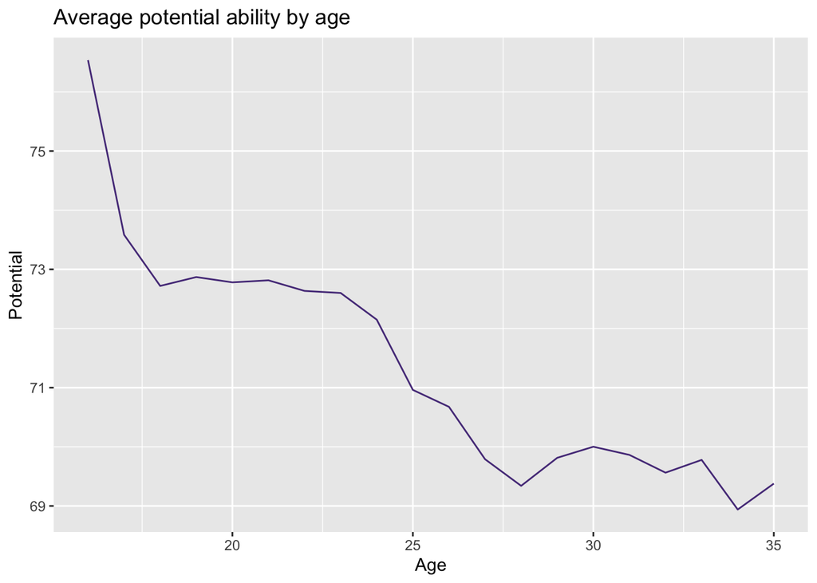

```r
under_35 <- filter(.data = fifa_players, Age <= 35)
under_35_potential <- under_35%>%group_by(Age)%>%summarise(Potential=mean(Potential)) # a mean potential ability for each age group
ggplot(data = under_35_potential, aes(x=Age, y=Potential)) +
  geom_line(col="#573b88") +
  xlim(16,35) +
  ggtitle(label = "Average potential ability by age")
```

*Average potential is higher for the youngest players but as a age rises the potential declines which does make sense in a real world observations*

2. Plot the *average difference* between a player’s `overall` ability to `potential` ability as a function of `age`, up to age 35. At what ages should we expect to find players for future development based on this graph?

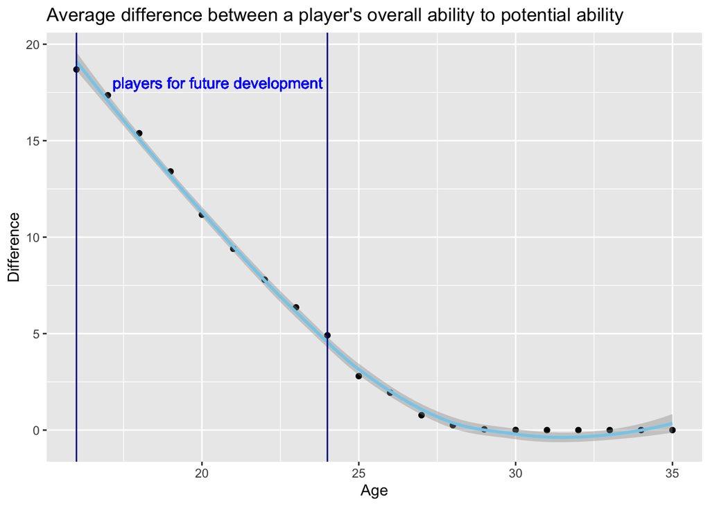

```r
under_35$Difference <- (under_35$Potential - under_35$Overall)
under35_diff <- aggregate(Difference ~ Age, data = under_35, FUN = mean)
ggplot(data = under35_diff, aes(x = Age, y = Difference)) +
  geom_point() +
  geom_smooth(col="skyblue")+
  xlim(16,35)+
  ggtitle(label = "Average difference between a player's overall ability to potential ability")+
  geom_vline(xintercept = c(16,24), col='darkblue')+
  geom_text(x=20.5, y=18, label="players for future development", col='blue')
```

*According to the graph, in ages from 16 to 24 we expect to find players for future development. After age of 24 average difference between overall and potential ability becomes less than 5, so it is irrational for the team to hire players older than 24, because there will not be any dramatic improvement in their overall ability.*

3. We are seeking young ($age \leq 21$) players with high `potential` ($>70$). Show a scatter plot of these players comparing their `potential` ability (x-axis) and current `value` (y-axis).  
   Find the 10 most-undervalued players, i.e. having the lowest `value` compared to their predicted value by `potential` using a simple linear regression model.  
   Calculate for each of them what is a fair `value` matching their `potential` that you be willing to pay in order to by them to your club and show these 10 players with their name, `age`, `overall` ability, `potential`, actual `value` and fair `value` in a table.

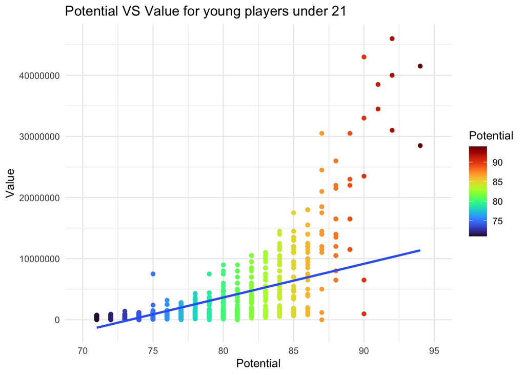

```r
best_young <- filter(.data = under_35, Age <= 21, Potential>70)
ggplot(data = best_young, aes(x = Potential, y=Value)) +
  geom_point(aes(col=Potential)) +
  xlim(70,95) +
  scale_color_viridis(option = "H")+
  theme_minimal() +
  theme(legend.position = "right")+
  ggtitle(label = "Potential VS Value for young players under 21")+
  geom_smooth(method = "lm",se = FALSE,lwd=1) #Regression line for value prediction according to young players potential
```

```r
###Showing 10 most-undervalued players having the lowest `value` compared to their predicted value by `potential` using a simple linear regression model
# Making a new data to do prediction
potential_prediction <- best_young[,c("Name","Age","Overall","Potential", "Value")]

# linear model:
lm_potential <- lm(Value ~ Potential, data = best_young)

#expected Y:
potential_prediction$Fair_value <- lm_potential$fitted.values

# Creating a difference column between a player's potential and his prediction.
# The bigger the difference, the more undervalues he is:

potential_prediction$difference <-  potential_prediction$Value-potential_prediction$Fair_value
potential_prediction <- arrange(.data = potential_prediction, difference)

potential_prediction$difference <- NULL
#10 most undervalues players:
print('10 most undervalued players: ')
```

```
## [1] "10 most undervalued players: "
```

```r
(head(x= potential_prediction, 10))
```

```
##              Name Age Overall Potential   Value Fair_value
## 1        A. Gomes  16      64        90  975000    9156458
## 2      W. Faríñez  19      73        87       0    7504532
## 3      M. Edwards  18      65        87 1200000    7504532
## 4       J. Sancho  17      63        86  800000    6953890
## 5      C. Früchtl  17      65        86  975000    6953890
## 6  E. Abouchabaka  17      62        85  650000    6403248
## 7    R. Sessegnon  17      67        86 1300000    6953890
## 8        V. Thill  17      63        85  800000    6403248
## 9          J. Arp  17      63        85  825000    6403248
## 10    B. Woodburn  17      65        85 1100000    6403248
```

4. Your boss wants to fly abroad to recruit promising players. Use the `rworldmap` package to display the world map and color each country based on the *median* `potential` of players from this nationality.

```r
promising_players <- aggregate(Potential ~ Nationality, data = fifa_players, FUN = median)
country_data<- joinCountryData2Map(dF = promising_players, joinCode = "NAME", nameJoinColumn = "Nationality") #worldmap
```

```
## 133 codes from your data successfully matched countries in the map
## 4 codes from your data failed to match with a country code in the map
## 110 codes from the map weren't represented in your data
```

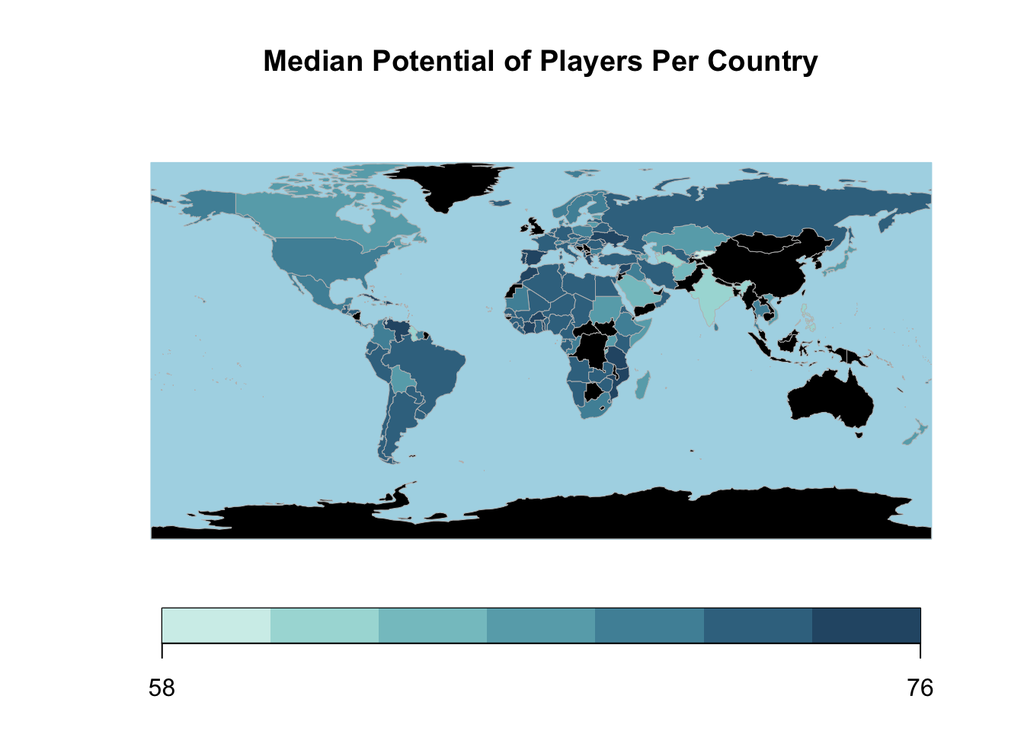

```r
world_map <- mapCountryData(country_data,nameColumnToPlot = "Potential",
             colourPalette = c('#d1eeea','#a8dbd9','#85c4c9','#68abb8','#4f90a6','#3b738f','#2a5674'),
             missingCountryCol = "black",
             oceanCol = "lightblue",
             catMethod = "fixedWidth",
             mapTitle = "Median Potential of Players Per Country", addLegend = T)
```

5. Repeat the above analysis but this time display a world map where each country is colored by the *median ratio* of `potential` to `value` of players. Find an under-valued country you’d recommend to travel to (i.e. a country with cheap players compared to their `potential` average quality).

```r
fifa$Value<- replace(fifa$Value, fifa$Value <=0,NA) #getting rid of Values=0, since we cant divide by 0

ratio_df <- aggregate(Potential/Value~ Nationality, data = fifa, FUN = median)
to_visit <-top_n(ratio_df,1,`Potential/Value`) #top-1 under-valued country you'd recommend to travel to
print("Country to travel: ")
```

```
## [1] "Country to travel: "
```

```r
print(to_visit)
```

```
##   Nationality Potential/Value
## 1  San Marino       0.0008857
```

```r
#creating the world map object:
ratio_df<- joinCountryData2Map(dF = ratio_df, joinCode = "NAME", nameJoinColumn = "Nationality")
```

```
## 132 codes from your data successfully matched countries in the map
## 4 codes from your data failed to match with a country code in the map
## 111 codes from the map weren't represented in your data
```

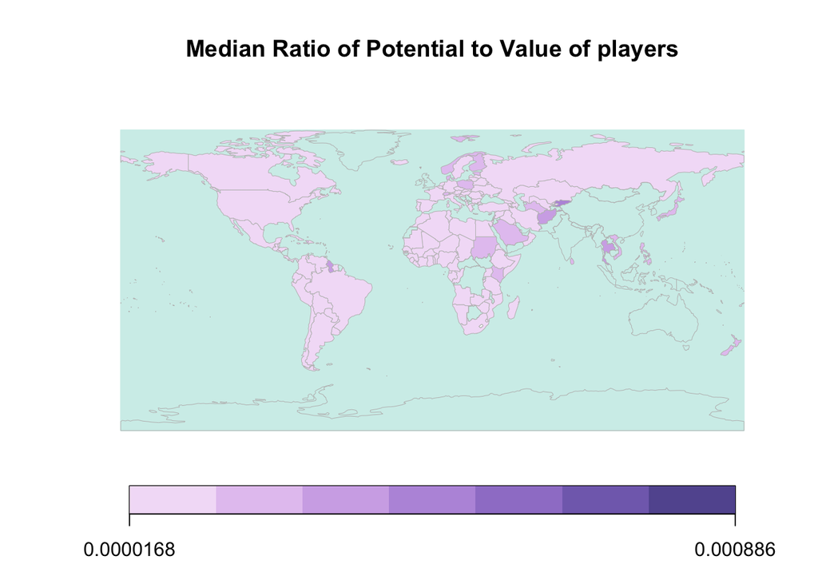

```r
#ploting the world map:
world_map <- mapCountryData(ratio_df,nameColumnToPlot = "Potential/Value",
             catMethod = "fixedWidth",
             colourPalette = c('#f3e0f7','#e4c7f1','#d1afe8','#b998dd','#9f82ce','#826dba','#63589f'),
             oceanCol = "#d1eeea", mapTitle = "Median Ratio of Potential to Value of players", addLegend = T)
```

*Recommeded country to travel is San Marino since its has biggest ratio of potential to value of players, meaning that San Marini has the cheapest players compared to their `potential` average quality.*

## Q3. Correlations Analysis (30 pt)

In this question we find and display different skills and their correlations

a.We are interested in finding out which positions are similar in terms of players’ performance. Extract the 26 non-goalkeeper positions (CAM, CB, …, ST). Calculate the correlation between players’ ability in each pair of positions and show a heatmap correlation-plot of the correlations’ matrix. What three positions have the least average correlations with other positions?

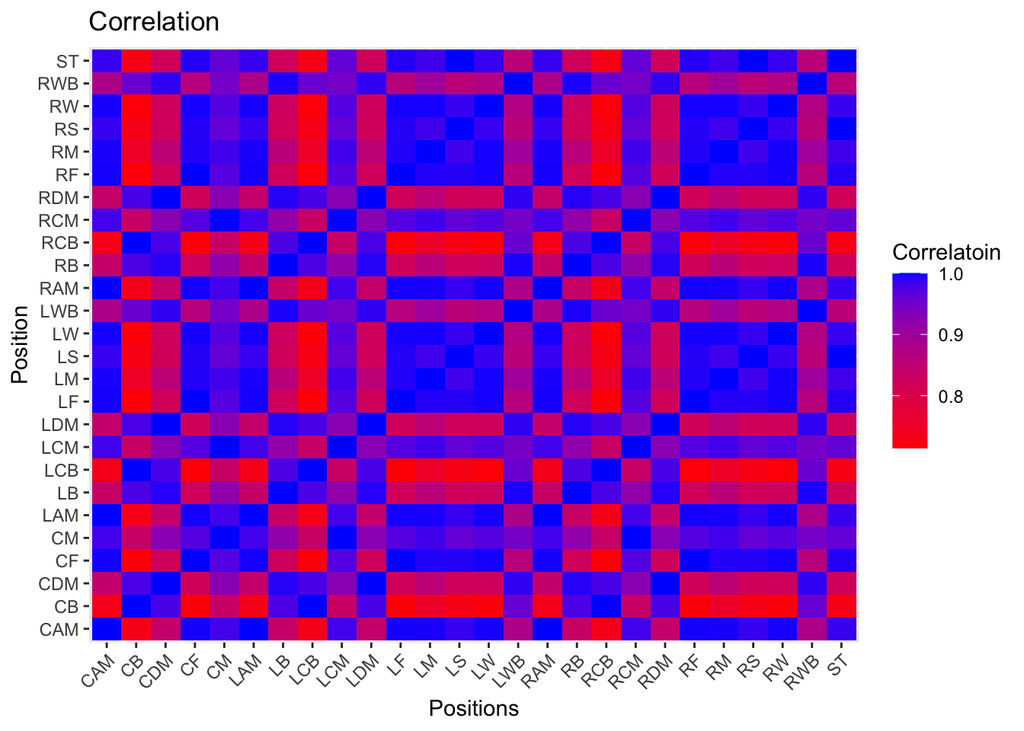

```r
positions<- names(fifa_players)[46:71]

cor_data <- expand.grid(x=positions,y=positions)
cor_data$cor=c(cor(fifa_players[,positions]))
ggplot(cor_data)+geom_tile(aes(x,y,fill=cor))+scale_fill_gradient(low = "red",high="blue")+
  labs(title = "Correlation",x="Positions",y="Position",fill="Correlatoin")+
  theme(axis.text.x = element_text(angle=45,hjust = 1))
```

```r
print("Least average correlated positions are:")
```

```
## [1] "Least average correlated positions are:"
```

```r
cor_data %>% filter(x!=y)%>% select(y,cor)%>%group_by(y)%>%summarise(mean_cor=mean(cor))%>% arrange(mean_cor) %>% head(3)
```

```
## # A tibble: 3 x 2
##   y     mean_cor
##   <fct>    <dbl>
## 1 CB       0.831
## 2 LCB      0.831
## 3 RCB      0.831
```

*According to the heat map the least average correlated positions are: CB, LCB, RCB.*

b.Consider the following indicators of players performance: overall players’ performance, their potential, their salary (wage) and their market value. Show a correlation-plot of players’ 34 skill levels (Acceleration, …, Volleys) vs. these four indicators. Find the 10 skills with the highest average correlation with the four inidcators and list them in a table.

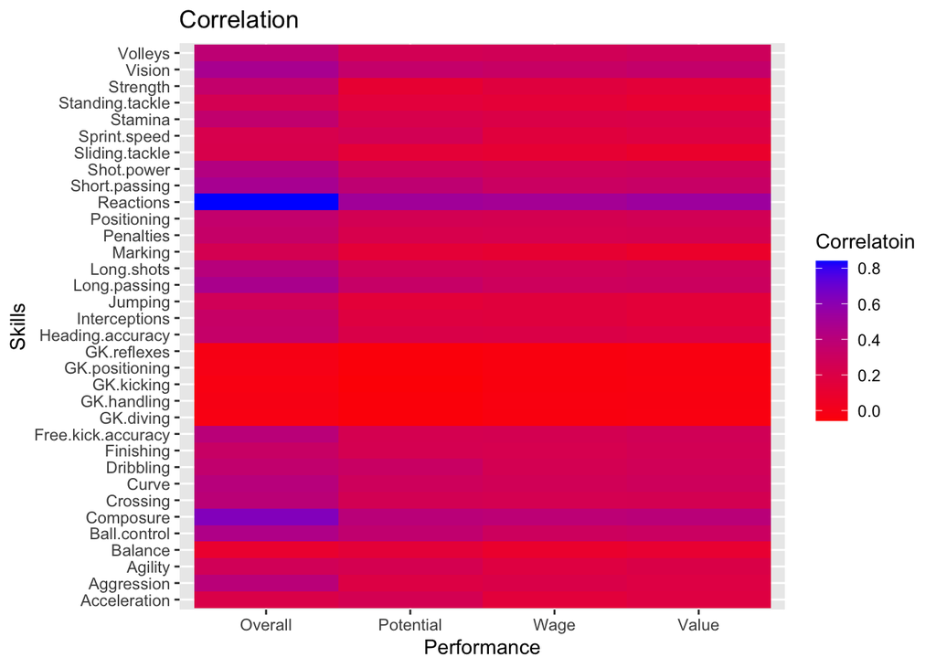

```r
skills<- fifa_players[,12:45]
performance <-fifa_players%>% select(Overall,Potential,Wage,Value)
cor_data <- expand.grid(x=names(skills),y=names(performance))
cor_data$cor=c(cor(skills,performance))
ggplot(cor_data)+geom_tile(aes(y,x,fill=cor))+scale_fill_gradient(low = "red",high="blue")+
  labs(title = "Correlation",x="Performance",y="Skills",fill="Correlatoin")
```

```r
skills_top10<-cor_data%>%group_by(x)%>%summarise(mean_cor=mean(cor))%>% arrange(desc(mean_cor))%>% head(10)
print('Top-10 skills with the highest average correlation with the overall players’ performance, potential, wage and  market value')
```

```
## [1] "Top-10 skills with the highest average correlation with the overall players’ performance, potential, wage and  market value"
```

```r
print(skills_top10)
```

```
## # A tibble: 10 x 2
##    x             mean_cor
##    <fct>            <dbl>
##  1 Reactions        0.599
##  2 Composure        0.458
##  3 Short.passing    0.375
##  4 Vision           0.375
##  5 Ball.control     0.355
##  6 Long.passing     0.350
##  7 Shot.power       0.318
##  8 Curve            0.314
##  9 Long.shots       0.309
## 10 Dribbling        0.299
```

3. Build a team of *11 different* players with the following rules:
- For each of the *26* non-goalkeaper positions (*26* from above plus goalkeaper, `GK`), find the player with the best performance at this position.
- Find the goal keaper (`Preffered.Positions` is `GK`) with the best `overall` performance.
- From the players obtained above, find *11 distinct* players maximizing the average `overall` performance of the team, with the constraint that there must be a goalkeaper (preferred position `GK`).
- List the players in a table including their `overall` performance and the team average `overall` score.  
  Next, peak six *different* players of your choice from your team, one of which is the goalkeaper. Using the function `radarchart::chartJSRadar`, graph their abilities (individually for all 6 players) in the top *10* skills according to 3.b in a [radar chart](https://en.wikipedia.org/wiki/Radar_chart) (also called ‘spider chart’) graph. See below an example for such a chart.

```r
#best players in different positions
best_perf<- c()
for(p in positions){
  best_perf<- c(best_perf,which(fifa_players[,p]==max(fifa_players[,p])))
}
#finding the player with  preferred GK position and the best overall
best_perf <- c(best_perf,
               which(fifa_players$Name==unlist(fifa_players %>%
                                                filter(str_detect(fifa_players$Preferred.Positions,"GK"))%>% arrange(desc(Overall))%>%select(Name)%>%head(1))))
print(head(best_perf,1))
```

```
## [1] 16315
```

```r
best_perf <- unique(best_perf)
min_ov<- fifa_players[best_perf,] %>% filter(Overall==min(Overall))%>%slice(sample(1:2,1))%>% select(Name)
#Creating a team with 11 players
(team <- fifa_players[best_perf,]%>% filter(Name!=min_ov$Name)%>% select(Name,Overall)%>% mutate(Team_overall=mean(Overall)))
```

```
##                 Name Overall Team_overall
## 1           L. Messi      93        88.73
## 2       Sergio Ramos      90        88.73
## 3           A. Vidal      87        88.73
## 4           T. Kroos      90        88.73
## 5        Azpilicueta      85        88.73
## 6        Alex Sandro      86        88.73
## 7            Marcelo      87        88.73
## 8  Cristiano Ronaldo      94        88.73
## 9           D. Alaba      86        88.73
## 10     R. Nainggolan      86        88.73
## 11          M. Neuer      92        88.73
```

```r
labs <-as.character(skills_top10$x)
#Peaking 6 different players from the team and creating heatmap according to their skills
players<- data.frame(random_players=sample((team$Name)[1:10],5,replace = FALSE))
random_players<-rbind(players,team$Name[11])
scores <-data.frame(t(fifa_players[fifa_players$Name%in%random_players$random_players,labs]))
names(scores)<- random_players$random_players
scores<- as.list(scores)
radarchart::chartJSRadar(scores=scores, labs=labs)
```

[interactive chart not shown]

4. We are interested in determining how the player’s abilities in different positions changes with age. Repeat the analysis of question 2.a., but this time show the *34* different skills  
   Which skills peak at youngest/oldest ages?

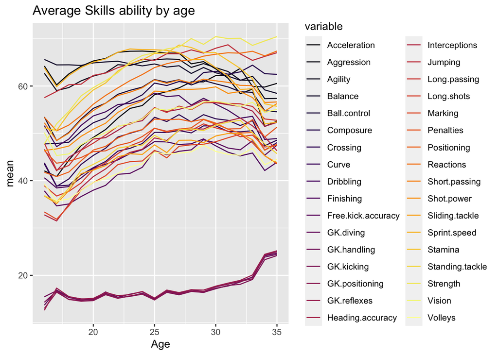

```r
under_35 <- filter(.data = fifa_players, Age <= 35)
under_35 <- under_35[,c("Age",names(skills))]
under35_skills<-melt(under_35, id.vars=c("Age"))
under35_skills%>%group_by(Age,variable)%>%summarise(mean=mean(value)) %>%ggplot(aes(x=Age,y=mean,col=variable))+geom_line() +
  xlim(16,35) + scale_color_viridis(discrete = TRUE, option = "B")+
  ggtitle(label = "Average Skills ability by age")
```

*According to the graphs, at young age Sprint Speed and Balance are at peaks; Strength, Jumping, Reaction and Composure are at peaks in older ages.*

5. Your boss suggests that some players may be currently under-payed compared to their performance, and that we can acquire them by offering them a higher salary (`wage`).  
   Fit a multiple regression model predicting player’s `overall` performance based on their `wage` and `age`.  
   Find the $10$ players with the highest difference between their `overall` performance level and the regression model prediction, and list them in a table.

```r
overall_prediction <- fifa_players[,c("Name","Overall")]


mod1<- lm(Overall~Age+Wage,data=fifa_players)

overall_prediction$Prediction <- mod1$fitted.values
overall_prediction$difference <-  overall_prediction$Overall-overall_prediction$Prediction
overall_prediction <- overall_prediction %>% arrange(desc(difference))
overall_prediction$difference <- NULL

print("Top-10 players with the highest difference between their `overall` performance level and the predicted")
```

```
## [1] "Top-10 players with the highest difference between their `overall` performance level and the predicted"
```

```r
(head(x= overall_prediction, 10))
```

```
##              Name Overall Prediction
## 1           Oscar      83      64.33
## 2       K. Mbappé      83      65.28
## 3    Adrien Silva      83      66.06
## 4     Sergio Rico      82      65.75
## 5            Fred      80      63.92
## 6   G. Donnarumma      82      65.92
## 7        Grimaldo      80      63.95
## 8       A. Witsel      82      66.06
## 9  Danilo Pereira      83      67.22
## 10     K. Dolberg      78      62.48
```

[figure not shown]

Example of a Spider chart

## Q4. Fix Problematic Plots (10 pt)

The previous data-analyst of the club was fired for producing poor plots. See below two bar plots that he made including their code.

1. Describe in your own words what did your predecessor try to show in each of the two plots.
2. Find *at least* three *different* problematic issues with his plots, and explain them.
3. Fix the problematic issues above in the code below to generate new, improved plots.  
   You will get an additional *bonus* point for finding any additional problem and fixing it.  
   (identifying the *same* problem in the two plots counts as *one* problem).

```r
# A measure of category's diversity
DIV <- function(category_vec){
  t <- table(category_vec)
  p <- t/sum(t)
  return(sum(p^2))
}

cleaned_data <- fifa_players %>% select(Nationality,Club) %>% na.omit()

number_of_nationality_in_club <- cleaned_data %>% group_by(Club, Nationality) %>% summarise(count = n()) %>% group_by(Club) %>% summarise(N_nation=n()) %>% arrange(desc(N_nation)) %>% mutate(Club = factor(Club, level=unique(Club)))
```

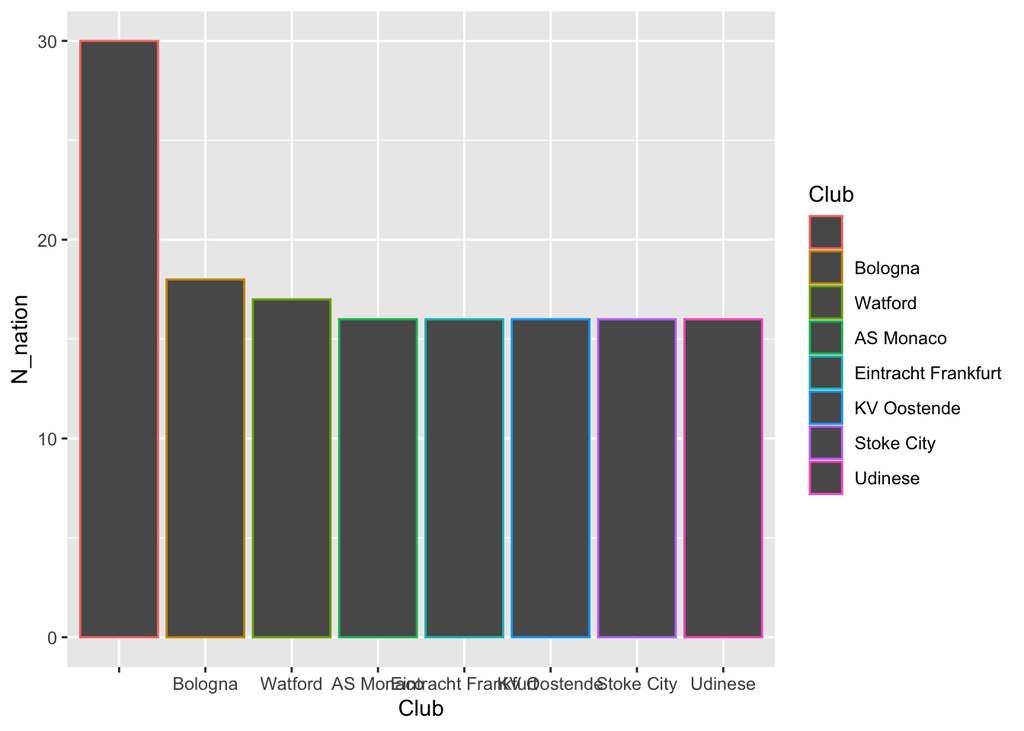

```r
DIV_in_club <- cleaned_data %>% group_by(Club) %>% summarise(DIV = DIV(Nationality))%>% arrange(DIV)%>% mutate(Club = factor(Club,level=unique(Club)))  # arrange(desc(DIV)) %>%

# Plot number of different nationalities in each club
g <- ggplot(data = number_of_nationality_in_club %>% head(8), aes(x = Club, y = N_nation,color = Club))
g + geom_bar(stat="identity")
```

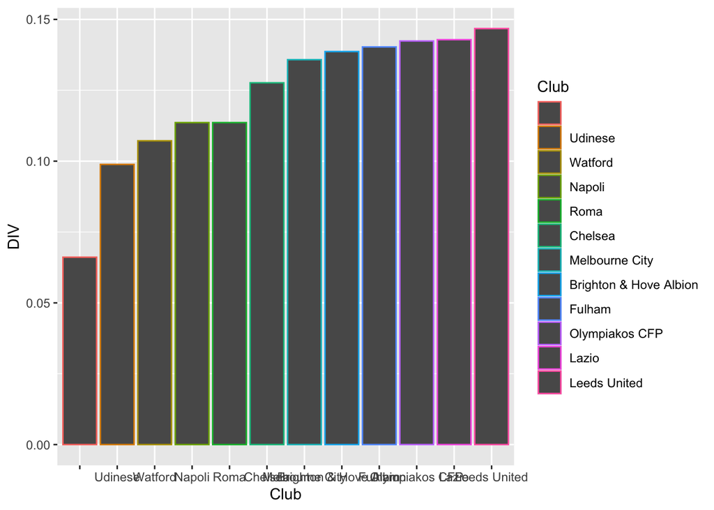

```r
# Plot DIV (diversity?) of different nationalities in each club
g <- ggplot(data = DIV_in_club %>% head(12),aes(x = Club,y = DIV, color = Club))
g <- g + geom_bar(stat="identity")
g
```

###***A)The plots are trying to show the nationality diversity within clubs.The first plot displays quantitatively how many different nations / countries each club have. As a result we see the top 8 nation diversified clubs. The second plot shows how many nations/countries proportionally are represented in top-12 diversifies clubs. It deals with the size of club and not overall distribution(because of course the bigger club => it will be more diversified),so this plot deals with the size of the club and calculates the diversification proportionally to each nationality/country.

#*B)Problems with the plots:* 1. There is no titles to the plots, so its not clear what are they trying to show. *2. There is column without name.* 3. The names of axes are not informative. *4. The names of the columns are unreadable.* 5. All of the columns are the same color, which makes the information unrepresented. *6. The first plot shows 8 clubs, while the second 12, so its hard ro proceed the comparison analysis between two plots.* 7. The code deals with NAs, however we dont have them, but it doesnt deal with blank spaces. *8. The construction of ggplot is tangled and not organized (pipes, g+, heads, but without lim for e.g).

#*C) Fixing mistakes:*

```r
DIV <- function(category_vec){
  t <- table(category_vec)
  p <- t/sum(t)
  return(sum(p^2))
}

cleaned_data <- fifa_players %>% select(Nationality,Club) %>% filter(Club!="")%>% filter(Nationality!="") #getting ris of blanks

number_of_nationality_in_club <- cleaned_data %>% group_by(Club, Nationality) %>% summarise(count = n()) %>% group_by(Club) %>% summarise(N_nation=n()) %>% arrange(desc(N_nation)) %>% mutate(Club = factor(Club, level=unique(Club)))
```

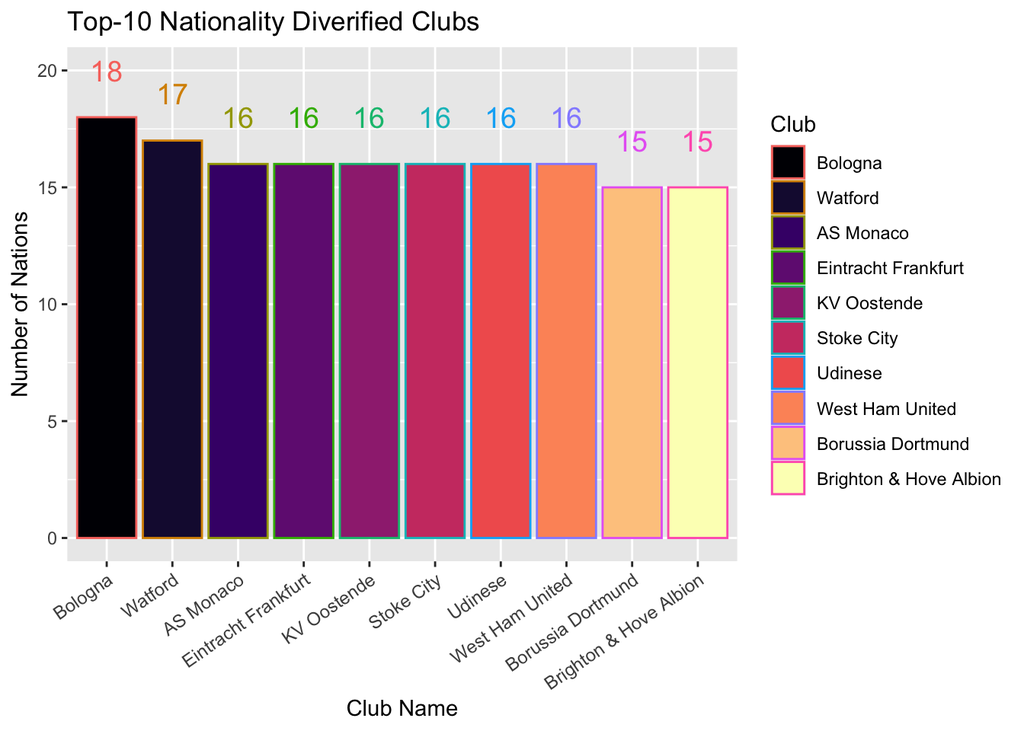

```r
DIV_in_club <- cleaned_data %>% group_by(Club) %>% summarise(DIV = DIV(Nationality))%>% arrange(DIV)%>% mutate(Club = factor(Club,level=unique(Club)))  # arrange(desc(DIV)) %>%

# Plot number of different nationalities in each club
gg1<-ggplot(data = number_of_nationality_in_club[1:10,], aes(x = Club,y = N_nation,color = Club, fill = Club)) +
  geom_bar(stat="identity") + ylab("Number of Nations") + xlab("Club Name")+
  ggtitle(label = "Top-10 Nationality Diverified Clubs") +
  theme(axis.text.x = element_text(angle = 35, hjust = 1, size = 9)) +
  geom_text(aes(y=N_nation + 2, label =  N_nation), lwd = 5, show.legend = F)
gg1+scale_fill_viridis_d(option="A")
```

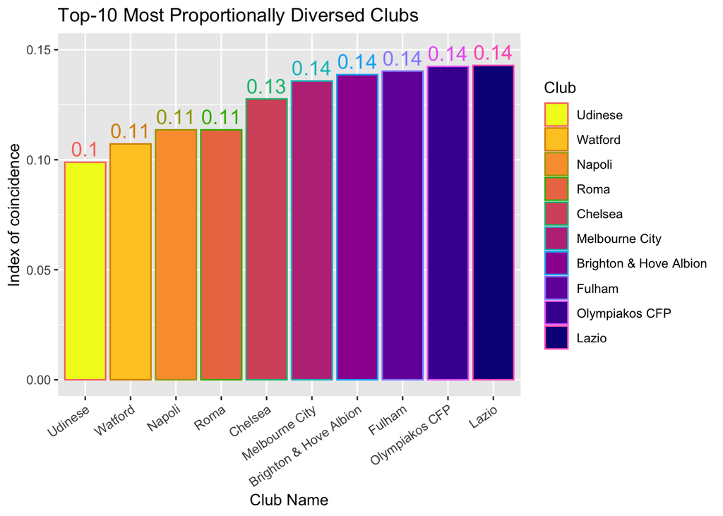

```r
# Plot DIV (diversity?) of different nationalities in each club
gg2<-ggplot(data = DIV_in_club[1:10,], aes(x = Club,y = DIV, color = Club, fill = Club)) +
  geom_bar(stat="identity") + ylim(0, 0.15)+ ylab("Index of coincidence") + xlab("Club Name")+
  ggtitle(label = "Top-10 Most Proportionally Diversed Clubs")+
  theme(axis.text.x = element_text(angle = 35, hjust = 1, size = 9)) +
  geom_text(aes(y=DIV + 0.006, label = round(DIV,2)), lwd = 5, show.legend = F)
gg2+scale_fill_viridis_d(option = 'C', direction=-1)
```